# Data analysis: Bike rides in the San Francisco bike-sharing system

## Investigation Overview

I analysed the dataset associated with the San Francisco bike-sharing system. I investigated when most of the bike rides were made (both the day of the week and the time of day) and what variables correlated with how long bike rides took.

## Dataset Overview

The data consisted of the attributes of 174,881 bike rides made in February of 2019. These attributes included the start and end stations, the start and end times, the type of user and the duration of the bike ride. 8531 data points were removed from the analysis because of missing values and incorrect ages.

## Data structure

The members were 75% male, 23% female and 2% other.

The median age of members is 32.

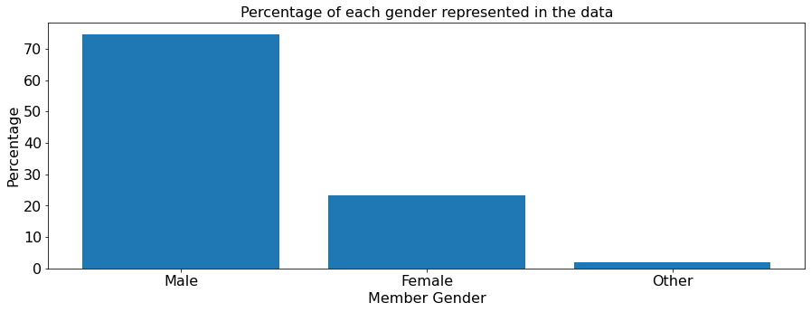

```
The members were 75% male, 23% female and 2% other.
```

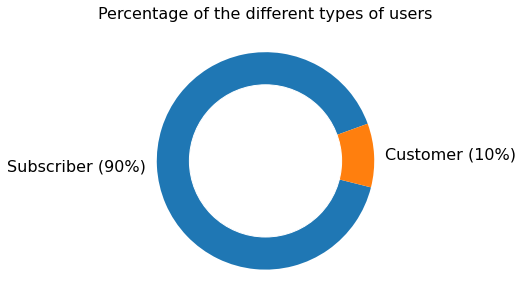

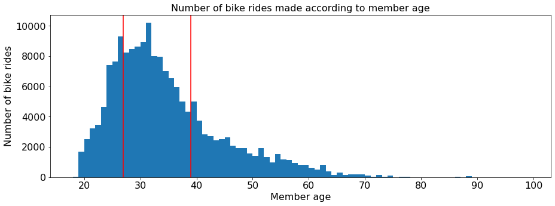

```
50% of the riders are aged between 27 and 39.
```

## Distribution of ride days and times

Compared to a weekday, there were were >50% fewer rides made on Saturday or Sunday.

The time of day shows a bimodal distribution, with the most rides being taken during commuting hours.

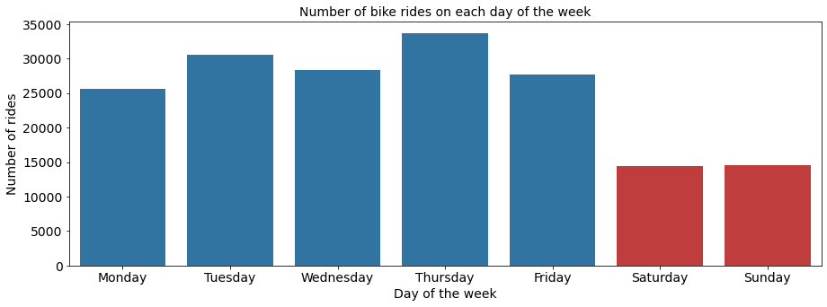

```
There were were >50% fewer rides made on Saturday or Sunday.
For example, 19% for Thursday vs. 8% for a Saturday.
```

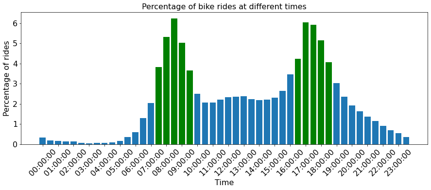

```
The highest usages were between 7:30 a.m. – 09:30 a.m. and 4:30 p.m. – 06:30 p.m.
```

## Distribution of ride duration

The time duration of each ride took on a large range of values. Under a log transformation, we see that the median duration is roughly 10 minutes, that most trips were between a few minutes to under an hour, and that no trip took longer than a day.

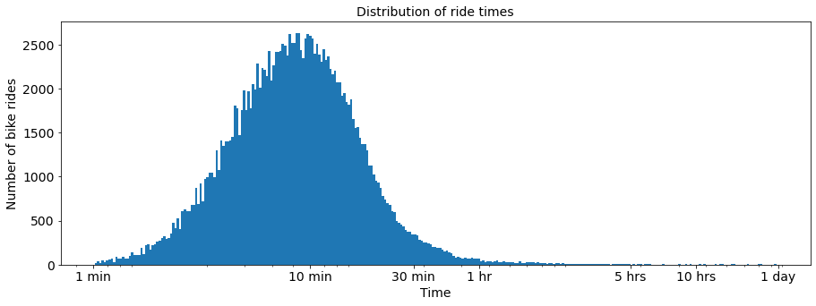

```
The median duration is roughly 10 minutes.
Most trips were between a few minutes to under an hour.
No trip took longer than a day.
```

## What are the ages of males/females who ride at the weekend/weekday?

For males and females at weekends (compared to weekdays):

- The median age is slightly lower
- Both the 25th and the 75th quartile are also at lower ages.

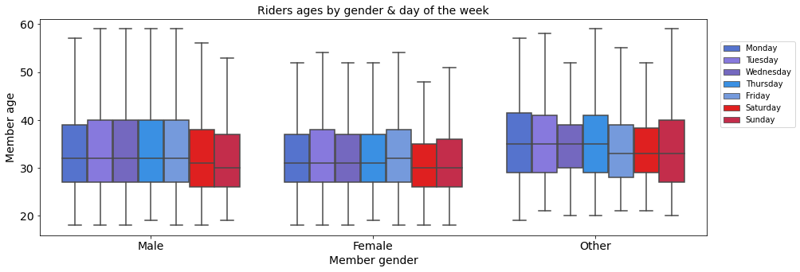

```
Note that the outliers have been removed; the box plots cover the interquartile range.
```

## Distribution of rider ages & ride times according to the day of the week

At weekends (compared to weekdays):  
The median age is slightly lower  
Both the 25th and the 75th quartile are also at lower ages.

The 75th quartile for ride duration time is slightly higher.

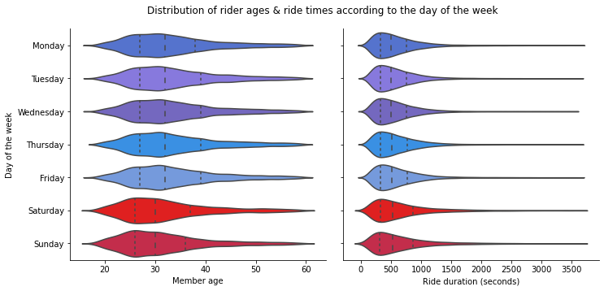

```
Again, the outliers have been removed and the box plots cover the interquartile range.
```

## Are there any other differences between the weekdays and the weekends?

At weekends, there is a different distribution for the most used stations and the most used bikes.

Lastly, the bimodal distribution of start times disappears at the weekend.

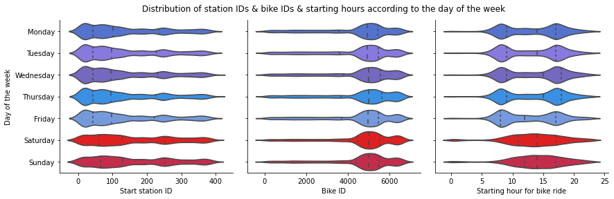

## Basic summary

- 174,881 bike rides were analysed.
- Median age of riders: 32. 75% of total were male.
- On the weekdays, commuting times were the busiest.
- There were fewer rides at the weekend.
- Median duration of each ride was roughly 10 minutes; most trips took a few minutes to under an hour.